# Forecasting Time Series Models: Problem Set 3

Linear regression models

```r
library(fpp2) # You will always load this package before analyzing any time series data.
library(lmtest)
```

### Question:

You own a shop that sells gifts, souvenirs, and novelties. The shop, opened in January 1987, is situated on the wharf at a beach resort town in Queensland, Australia. The sales volume varies with the seasonal population of tourists. There is a massive influx of visitors to the town at Christmas and for the local surfing festival, held every March since 1988.

You are interested in expanding the premises, the range of products, and staff overtime. To extend your business, you need to forecast future sales. The data set `fancy` concerns the monthly sales figures for this shop.

1- Produce a time plot of the data and describe the patterns in the graph. Identify any unusual or unexpected fluctuations in the time series.

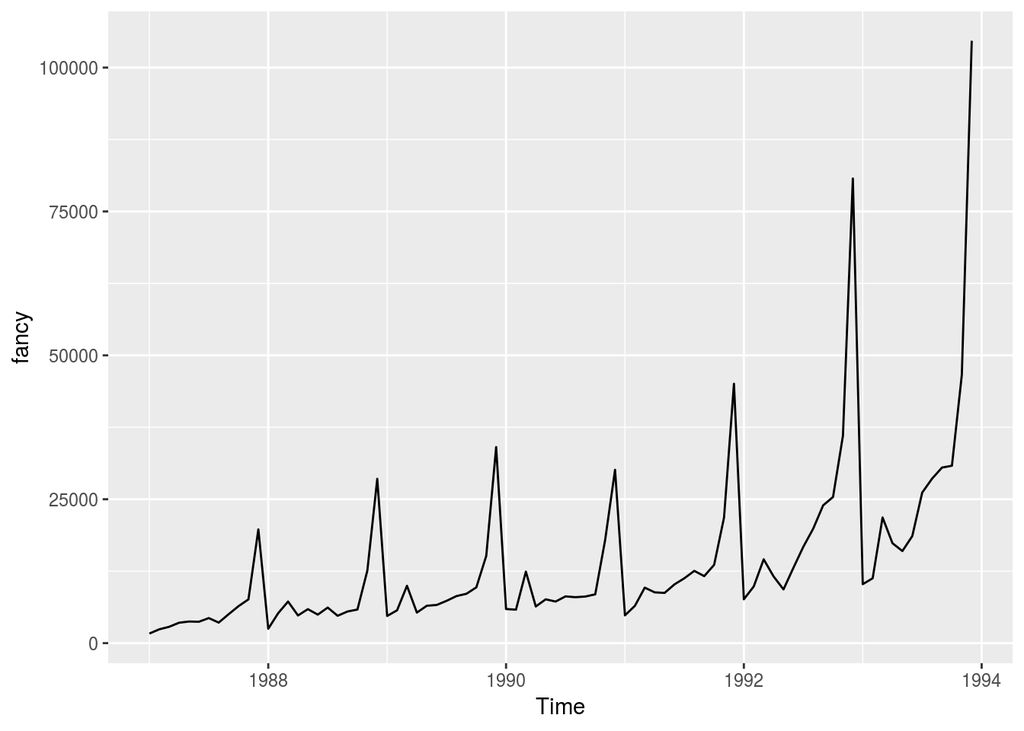

```r
autoplot(fancy)
```

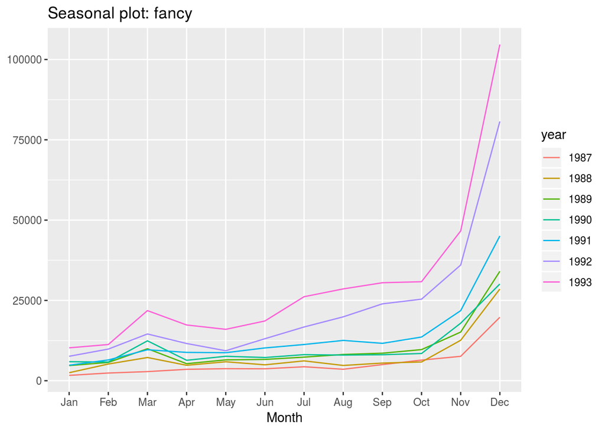

```r
ggseasonplot(fancy)
```

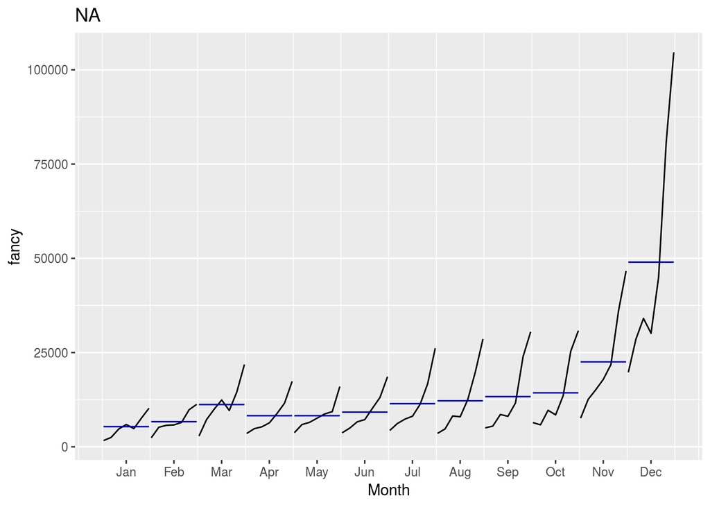

```r
ggsubseriesplot(fancy)
```

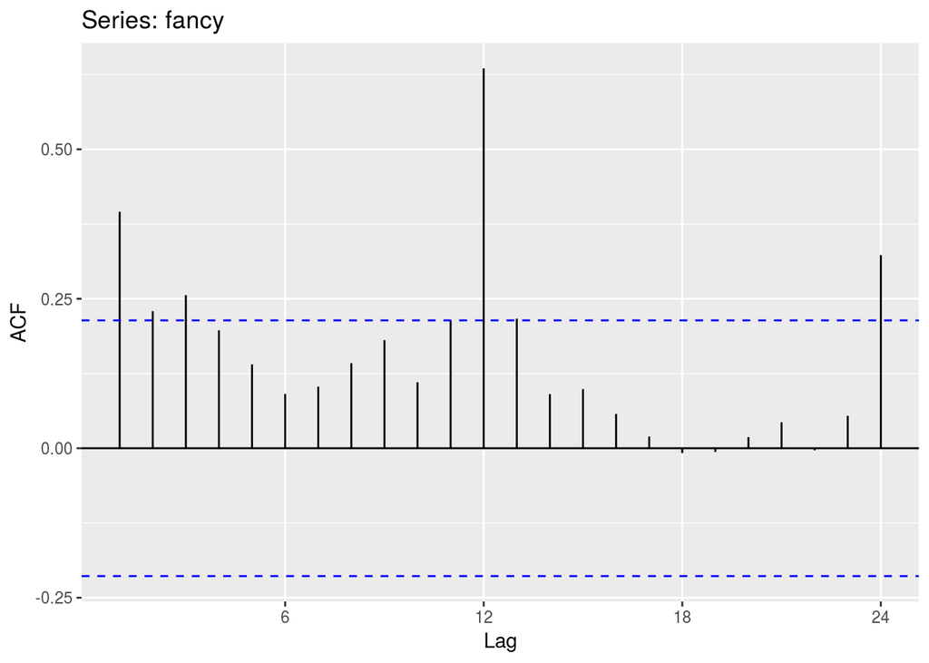

```r
ggAcf(fancy)
```

```r
Box.test(fancy,type = "Ljung-Box")
```

```
##
##  Box-Ljung test
##
## data:  fancy
## X-squared = 13.622, df = 1, p-value = 0.0002235
```

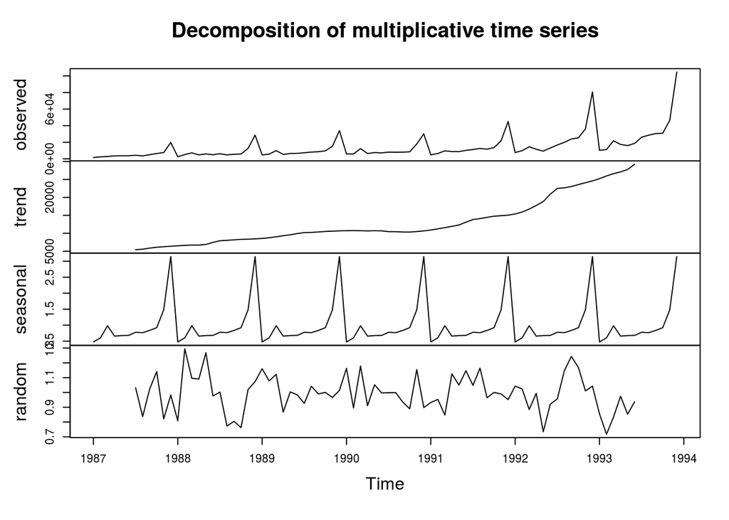

```r
plot(decompose(fancy, type = "multiplicative"))
```

2- Explain why it is necessary to take logarithms of these data before fitting a model. With the positive trend in the data, we would want the logarithms of the data to take out the trend and focus on the seasonal nature of the data.

3- Use R to fit a regression model to the logarithms of these sales data with a linear trend, seasonal dummies and a *surfing festival* dummy variable.

```r
surf.fest <- cycle(fancy)==3
surf.fest[3] <- FALSE
mod <- tslm(log(fancy) ~ trend + season + surf.fest, data = fancy)
summary(mod)
```

```
##
## Call:
## tslm(formula = log(fancy) ~ trend + season + surf.fest, data = fancy)
##
## Residuals:
##      Min       1Q   Median       3Q      Max
## -0.33673 -0.12757  0.00257  0.10911  0.37671
##
## Coefficients:
##                Estimate Std. Error t value Pr(>|t|)
## (Intercept)   7.6196670  0.0742471 102.626  < 2e-16 ***
## trend         0.0220198  0.0008268  26.634  < 2e-16 ***
## season2       0.2514168  0.0956790   2.628 0.010555 *
## season3       0.2660828  0.1934044   1.376 0.173275
## season4       0.3840535  0.0957075   4.013 0.000148 ***
## season5       0.4094870  0.0957325   4.277 5.88e-05 ***
## season6       0.4488283  0.0957647   4.687 1.33e-05 ***
## season7       0.6104545  0.0958039   6.372 1.71e-08 ***
## season8       0.5879644  0.0958503   6.134 4.53e-08 ***
## season9       0.6693299  0.0959037   6.979 1.36e-09 ***
## season10      0.7473919  0.0959643   7.788 4.48e-11 ***
## season11      1.2067479  0.0960319  12.566  < 2e-16 ***
## season12      1.9622412  0.0961066  20.417  < 2e-16 ***
## surf.festTRUE 0.5015151  0.1964273   2.553 0.012856 *
## ---
## Signif. codes:  0 '***' 0.001 '**' 0.01 '*' 0.05 '.' 0.1 ' ' 1
##
## Residual standard error: 0.179 on 70 degrees of freedom
## Multiple R-squared:  0.9567, Adjusted R-squared:  0.9487
## F-statistic:   119 on 13 and 70 DF,  p-value: < 2.2e-16
```

4- Plot the residuals against time and against the fitted values. Do these plots reveal any problems with the model?

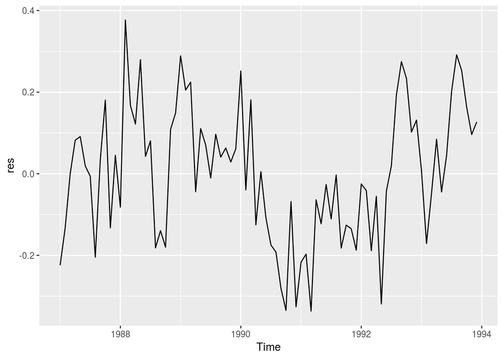

```r
res <- residuals(mod)
autoplot(res)
```

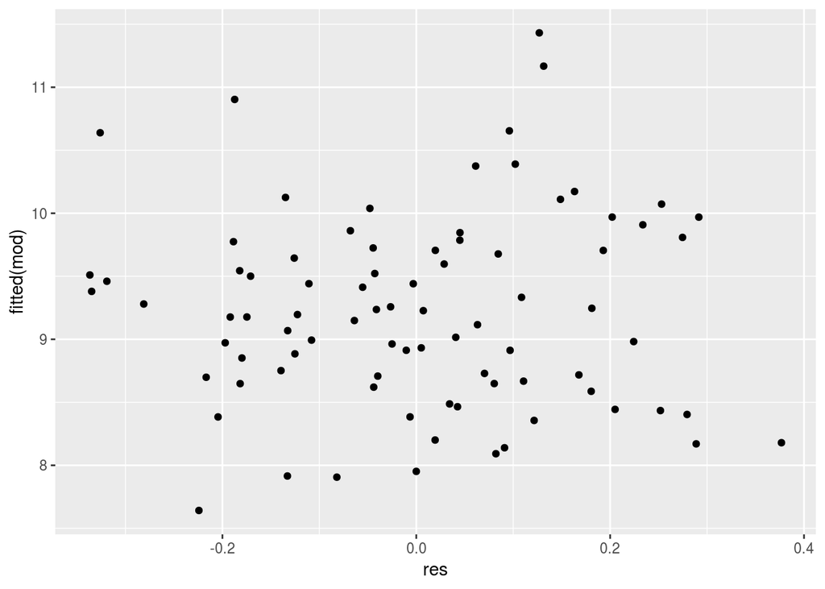

```r
ggplot(fancy,aes(x = res, y = fitted(mod))) + geom_point()
```

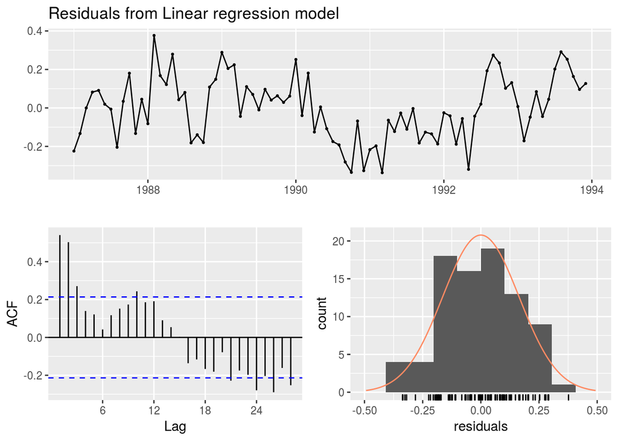

```
##
##  Breusch-Godfrey test for serial correlation of order up to 17
##
## data:  Residuals from Linear regression model
## LM test = 37.954, df = 17, p-value = 0.002494
```

```r
checkresiduals(mod)
```

5- Do boxplots of the residuals for each month. Does this reveal any problems with the model?

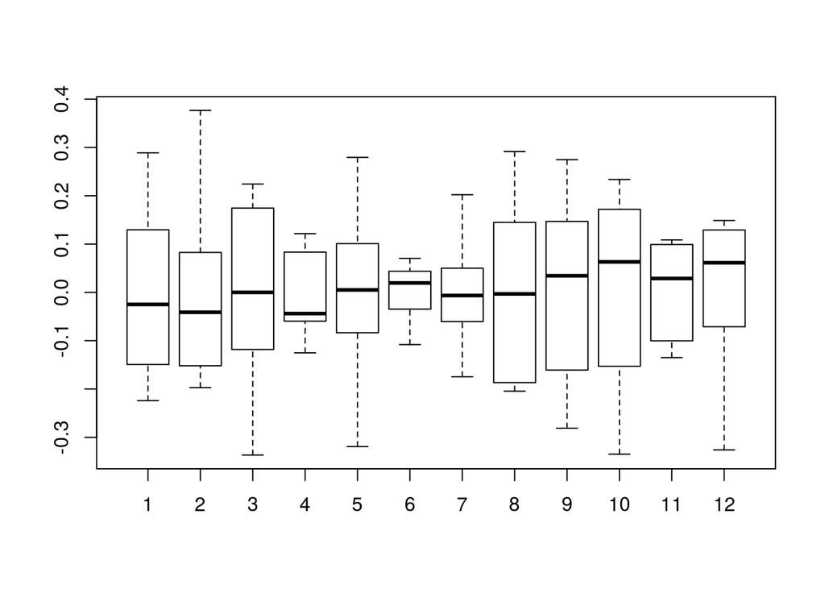

```r
boxplot(residuals(mod)~cycle(residuals(mod)))
```

7- What does the Breusch-Godfrey test tell you about your model?

```r
bgtest(mod, fill = NA)
```

```
##
##  Breusch-Godfrey test for serial correlation of order up to 1
##
## data:  mod
## LM test = 25.796, df = 1, p-value = 3.795e-07
```

The Breusch-Godfrey test gives a p-value of 3.795e-07 which means the null hypothesis is reject. So there is serial correlation in the model.

8- Regardless of your answers to the above questions, use a regression model to predict the monthly sales for 1994, 1995, and 1996. Produce prediction intervals for each of your forecasts.

```r
pred <- forecast(mod,newdata = data.frame(surf.fest = rep(FALSE,36)))
pred
```

```
##          Point Forecast     Lo 80     Hi 80     Lo 95    Hi 95
## Jan 1994       9.491352  9.238522  9.744183  9.101594  9.88111
## Feb 1994       9.764789  9.511959 10.017620  9.375031 10.15455
## Mar 1994       9.801475  9.461879 10.141071  9.277961 10.32499
## Apr 1994       9.941465  9.688635 10.194296  9.551707 10.33122
## May 1994       9.988919  9.736088 10.241749  9.599161 10.37868
## Jun 1994      10.050280  9.797449 10.303110  9.660522 10.44004
## Jul 1994      10.233926  9.981095 10.486756  9.844168 10.62368
## Aug 1994      10.233456  9.980625 10.486286  9.843698 10.62321
## Sep 1994      10.336841 10.084010 10.589671  9.947083 10.72660
## Oct 1994      10.436923 10.184092 10.689753 10.047165 10.82668
## Nov 1994      10.918299 10.665468 11.171129 10.528541 11.30806
## Dec 1994      11.695812 11.442981 11.948642 11.306054 12.08557
## Jan 1995       9.755590  9.499844 10.011336  9.361338 10.14984
## Feb 1995      10.029027  9.773281 10.284773  9.634775 10.42328
## Mar 1995      10.065713  9.722498 10.408928  9.536620 10.59481
## Apr 1995      10.205703  9.949957 10.461449  9.811451 10.59996
## May 1995      10.253157  9.997411 10.508903  9.858904 10.64741
## Jun 1995      10.314518 10.058772 10.570264  9.920265 10.70877
## Jul 1995      10.498164 10.242418 10.753910 10.103911 10.89242
## Aug 1995      10.497694 10.241948 10.753440 10.103441 10.89195
## Sep 1995      10.601079 10.345333 10.856825 10.206826 10.99533
## Oct 1995      10.701161 10.445415 10.956907 10.306908 11.09541
## Nov 1995      11.182537 10.926791 11.438282 10.788284 11.57679
## Dec 1995      11.960050 11.704304 12.215796 11.565797 12.35430
## Jan 1996      10.019828  9.760564 10.279093  9.620151 10.41951
## Feb 1996      10.293265 10.034000 10.552530  9.893588 10.69294
## Mar 1996      10.329951  9.982679 10.677222  9.794605 10.86530
## Apr 1996      10.469941 10.210677 10.729206 10.070264 10.86962
## May 1996      10.517395 10.258130 10.776659 10.117718 10.91707
## Jun 1996      10.578756 10.319491 10.838021 10.179079 10.97843
## Jul 1996      10.762402 10.503137 11.021667 10.362725 11.16208
## Aug 1996      10.761932 10.502667 11.021196 10.362254 11.16161
## Sep 1996      10.865317 10.606052 11.124582 10.465640 11.26499
## Oct 1996      10.965399 10.706134 11.224664 10.565722 11.36508
## Nov 1996      11.446774 11.187510 11.706039 11.047097 11.84645
## Dec 1996      12.224288 11.965023 12.483552 11.824611 12.62396
```

9- How could you improve these predictions by modifying the model? According to the Breusch-Godfrey test indicating that there is serial correlation in the model, it would be best to capture this information to improve the model. This can be acheived by taking the log of all variables, or ridding of seasonality.